# Day 1 Part 2

# Learning Objectives

In this lesson, we will go over the followings:

- What is R and Why R?
- RStudio IDE
- Basics
  - Commands, assignments, and objects
  - Code, data, and file organization
  - Getting help and use help
  - loops, if statements
- Writing the good code

[figure not shown]

# What is R and Why R?

- “it consists of a language plus a run-time environment with graphics, a debugger, access to certain system functions, and the ability to run programs stored in script files”
- Developed in 1992 by Ross Ihaka and Robert Gentleman at the University of Auckland
- In top-3 programming languages for data science
  - R was **ranked #1** in the KDnuggets 2014 poll on Top Languages for analytics
- Using R:
  - New users should work with the integrated development environment (IDE) called RStudio

[figure not shown]

# The RStudio IDE

[figure not shown]

Create a New Project – Step 1

[figure not shown]

## Create a New Project – Step 2

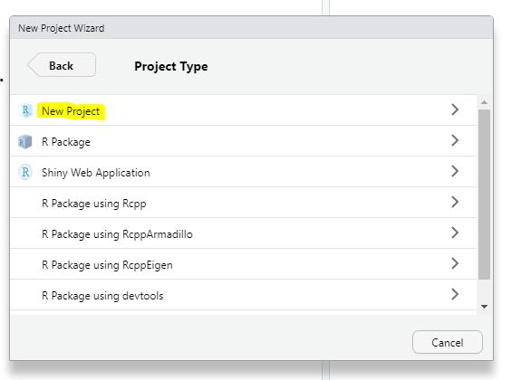

[figure not shown]

# Working with console:

The basic approach to using R interactively is to type a command and hit Enter

```r
10 - 6
```

```
## [1] 4
```

The result that R returns, 4, has as [1] at the left side of the line. This number simply indicates the position of the adjacent element in the output{this will make more sense later when the output has more elements

- Multi-line commands, an R console will display a “continuation symbol” +

```r
 10 -
+ 6
```

```
## [1] 4
```

hit Enter before typing the 6

The continuation character indicates that R is waiting for something

To see what is contained within a symbolic variable, type its name

```r
x <- 10
x
```

```
## [1] 10
```

- Recall a previous command in an R console by hitting the up arrow on your keyboard
- When you give R an assignment, such as the one above, the object referred to as x is stored in your workspace
  - ls(): list all the objects in the your workspace
  - rm(x): remove the object from your workspace
  - rm (list=ls()) : what does this do?
- **R is a case-sensitive language**
- If you are stuck in a bad command in the console, just hit the **Esc**

# The RStudio IDE with script editor

[figure not shown]

## RStudio

- It is now much more than a script editor, and includes tools for building packages and writing dynamic reports, among others
- The lower left window is the console by default
- You can click within it and interact directly with R
- If your code is worth writing, it is probably worth saving
- Don’t write it in the console, write it in a R script file.
- You can then repeat the same analysis in the future

[figure not shown]

**Comments**: create a comment with the comment character #

```r
# Notes from Day 1 of Intro to R
# M. Zihayat
# you can use ctrl+shift+C to comment a line
```

**Working directory:** Tells R where to look for files that are to be read in, and where to write files.

- When you create a project, it is set to your project folder by default

Two ways to set it:

- Session menu
- Commands:

  ```r
  getwd() #tells you the current directory
  ```

  ```
  ## [1] "C:/Users/Morteza/Documents/RStudio/Intro to R - Day 1"
  ```

  ```r
  setwd('C:/Users/Morteza/Documents/RStudio/Intro to R - Day 1')#set the current directory
  ```

## Run a script in RStudio

  **CTRL + Enter** Run current line or selection

  **CTRL + Shift + Enter** Run all lines

[figure not shown]

## Commands, assignment, and objects

- The R language is a mix of functional and object-oriented style
- Most (technically all) of the operations carried out in R are done by calling up functions, e.g., sqrt(10) will calculate the square root of 10
- The variables you create and work with in R are called **objects**
- Objects are really anything that can be assigned to a symbolic variable; data structures (e.g., a matrix) and functions (e.g., sqrt) are examples of objects
- Many functions in R operate differently on different types of objects

[figure not shown]

## Operators

```r
10^3.5 + 87*3.2 - 1000/18
```

```
## [1] 3385.122
```

## Relational operators: ==, !=, <, >, <=, >=

```r
a <- 50
a >= 100
```

```
## [1] FALSE
```

## Default Functions

- The central computation in R is a function call
- Functions require arguments, which are the objects that the function should act upon and other instructions for the function

```r
sqrt(10)
```

```
## [1] 3.162278
```

you can bring up the help page for any function by typing ? followed by the function name

```
?sqrt
```

## Mathematical functions

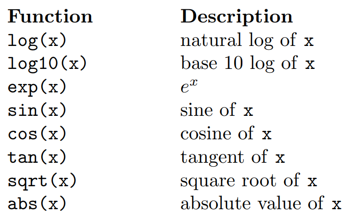

```r
x <- pi/2 + 0.2
a <- sin(x)
b <- round(a, 2)
```

Or

```r
 round(sin(pi/2 + 0.2), 2)
```

```
## [1] 0.98
```

Generic functions

The functions with general name while their functionality changes with respect to the input parameters.

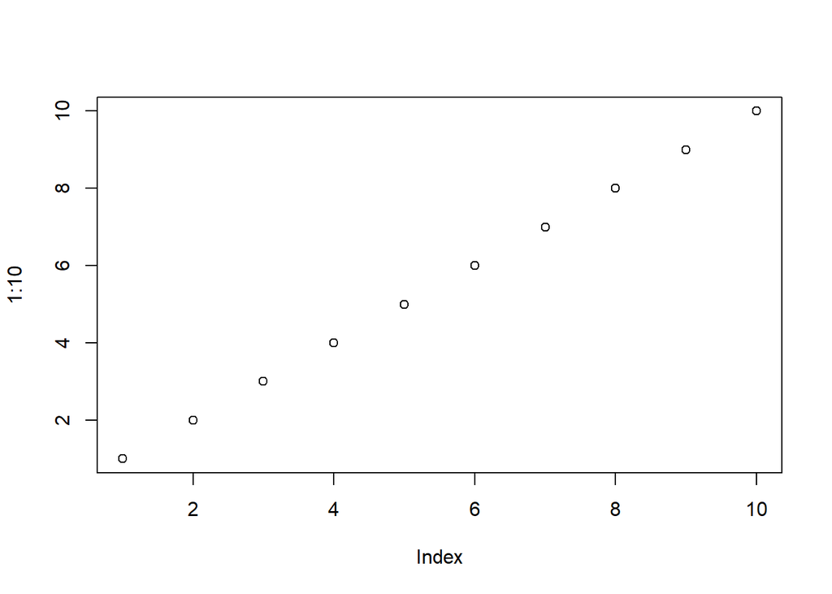

```r
 plot(1:10)
```

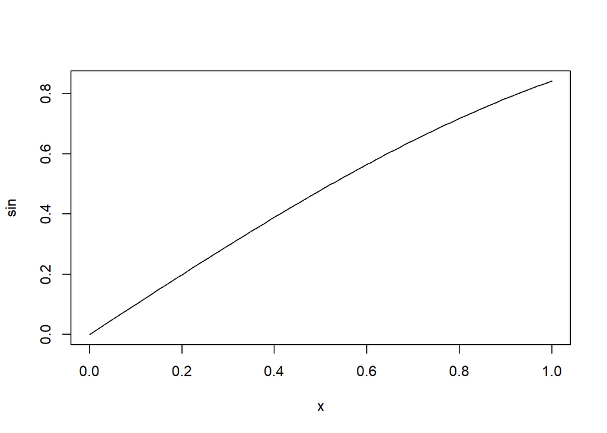

```r
plot(sin)
```

see all the functionalities:

```r
methods(plot)
```

```
##  [1] plot.acf*           plot.data.frame*    plot.decomposed.ts*
##  [4] plot.default        plot.dendrogram*    plot.density*
##  [7] plot.ecdf           plot.factor*        plot.formula*
## [10] plot.function       plot.hclust*        plot.histogram*
## [13] plot.HoltWinters*   plot.isoreg*        plot.lm*
## [16] plot.medpolish*     plot.mlm*           plot.ppr*
## [19] plot.prcomp*        plot.princomp*      plot.profile.nls*
## [22] plot.raster*        plot.spec*          plot.stepfun
## [25] plot.stl*           plot.table*         plot.ts
## [28] plot.tskernel*      plot.TukeyHSD*
## see '?methods' for accessing help and source code
```

[figure not shown]

## **Common R Functions and Control Flow**

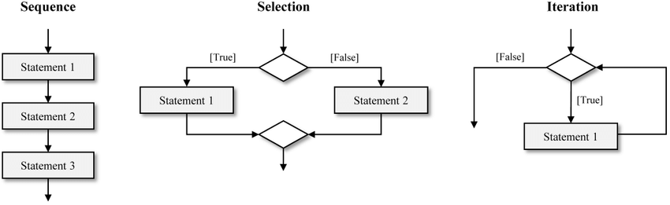

**`if… else` Statements**

```
if (test_expression) {
statement1
} else {
statement2
}
```

```r
if (50 < 30){
    print("50 < 30.")
}else{
    print("50 >= 30.")
    print("The else code block was run instead of the first block.")
}
```

```
## [1] "50 >= 30."
## [1] "The else code block was run instead of the first block."
```

```r
print('---')
```

```
## [1] "---"
```

```r
print('These two lines are not indented, so they are always run next.')
```

```
## [1] "These two lines are not indented, so they are always run next."
```

## **`for` Loops**

- One of the primary purposes of using a programming language is to automate repetitive tasks. One example is the `for` loop.
- The `for` loop allows you to perform a task repeatedly on every element within an object, such as every name in a list.

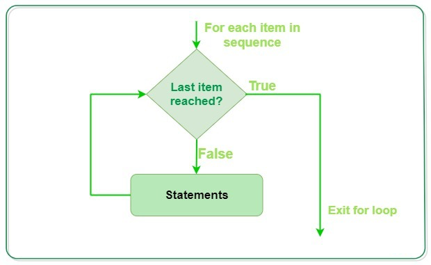

```r
names <- c('Rebecca Bunch', 'Paula Proctor', 'Heather Davis')

for (val in names) {
  print(val)
}
```

```
## [1] "Rebecca Bunch"
## [1] "Paula Proctor"
## [1] "Heather Davis"
```

[figure not shown]

# Working with add-on packages

- While the base packages include many useful functions, for specialized procedures you may need content from add-on packages.
- CRAN website http://cran.r-project.org/ currently lists more than 4000 add-on packages

  ```
  install.packages("dplyr")
  ```

load a package

```r
library("dplyr")
```

## The tidyverse packages

- One of the most important of these is dplyr, which is designed for data manipulation
- The dplyr package and 11 others that share some approaches to programming are collectively referred to as the tidyverse, or tidyverse packages  
  The most important of these packages are:  
  • **dplyr**, for data manipulation  
  • **magrittr**, which defines the forward pipe operator  
  • **ggplot2**, which can be used to make sophisticated plots without much effort  
  • **lubridate**, for working with dates and times  
  • **tibble**, which defines a new type of data frame  
  • **readr**, for reading in data from text files  
  • **readxl**, for reading data from Excel files  
  • **tidyr**, for reshaping data frames to make “tidy” data
- These packages are great
- the syntax of these packages is not completely consistent with base R
- the functions are not always consistent with other functions

  ```
  install.packages("tidyverse")
  ```

  ```r
  library(tidyverse)
  ```

[figure not shown]

## Writing good code

- Good codes bring reusability:
  - Include comments in your scripts
  - Use spaces between object names, operators, and constants
  - Indent code in order to see clearly what belongs where
  - Stick with lowercase object and column names
  - Use blank lines to separate blocks of code

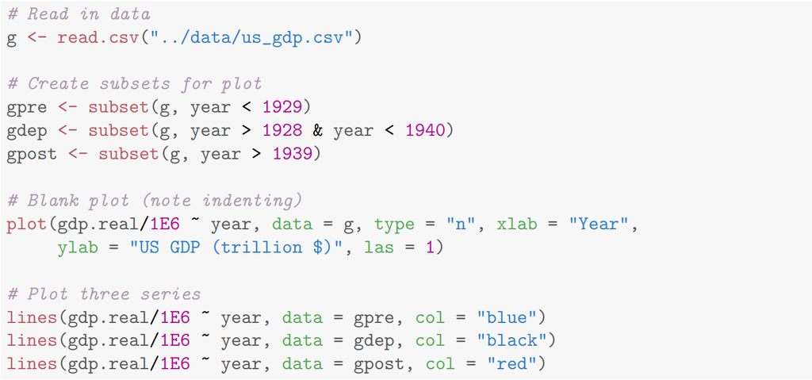

  Data organization

  1. Header rows are only present at the top of the file

  2. Each column contains a single variable

  3. Each row contains a single observation

  4. Each file (or worksheet) contains a single block of data

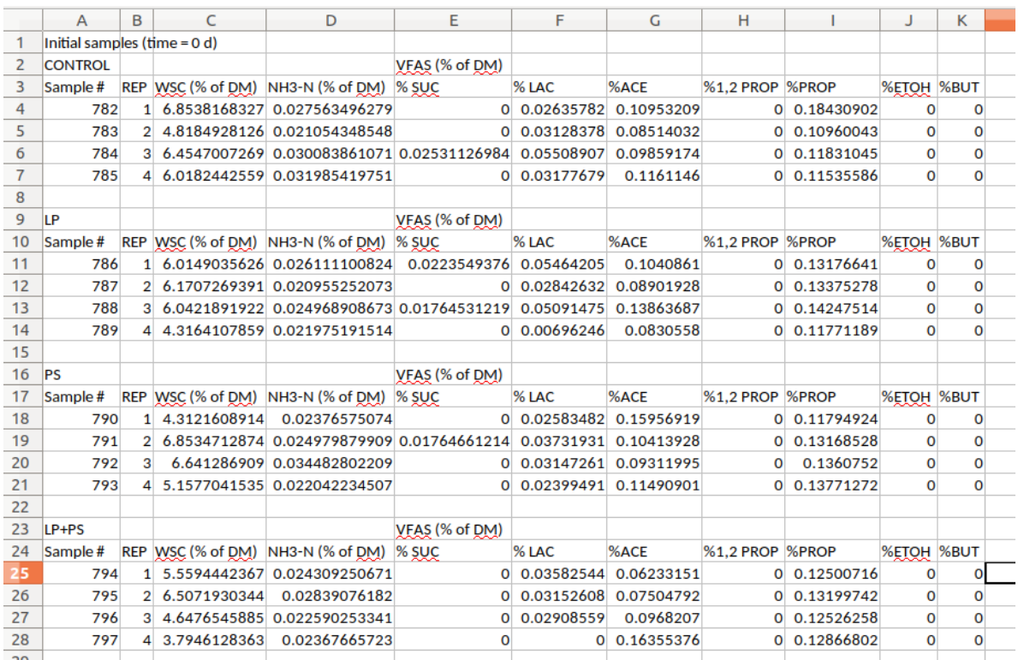

  File organization and workflow
- It is very easy to make a mess of file organization
- We want to get to an answer quickly
- Each project, should have a separate folder containing all project files
- One suggestion:

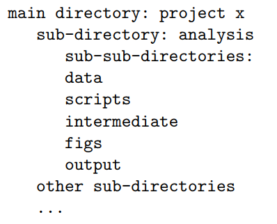

- The “scripts” directory contains all R scripts
- “figs” and “output” contain graphical and other output.
- The “intermediate” directory is used for intermediate data sets that need to be saved.
- Automate every step:
  - Try to avoid any data processing in Excel

## Getting help

- CRAN website (http://cran.r-project.org/manuals.html
- Frequently Asked Questions on CRAN (http://cran.r-project.org/faqs.html) answers a lot of basic questions
- R site search" ([http://finzi.psych.upenn.edu/search.html)](http://finzi.psych.upenn.edu/search.html))
- Mailing lists:
  - You can sign up for any of the lists here: http://www.r-project.org/mail.html. Before posting a question, be sure to search the mailing list archives, and check the posting guide (http://www.r-project.org/posting-guide.html).